# Flex Dashboard

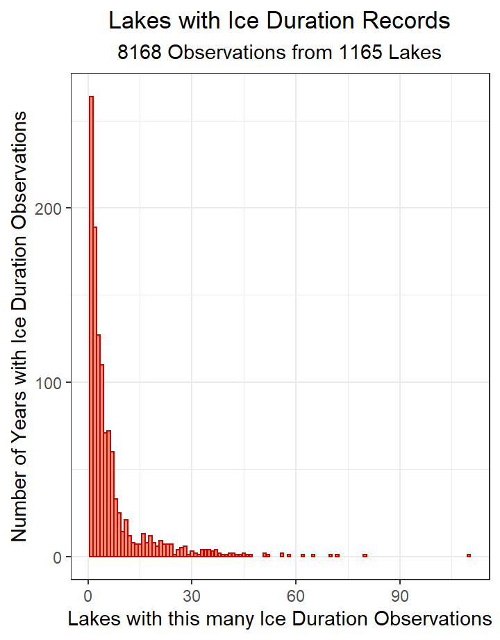

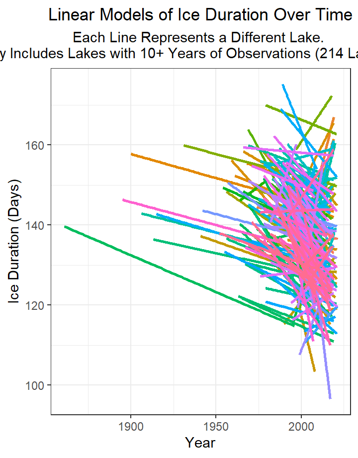

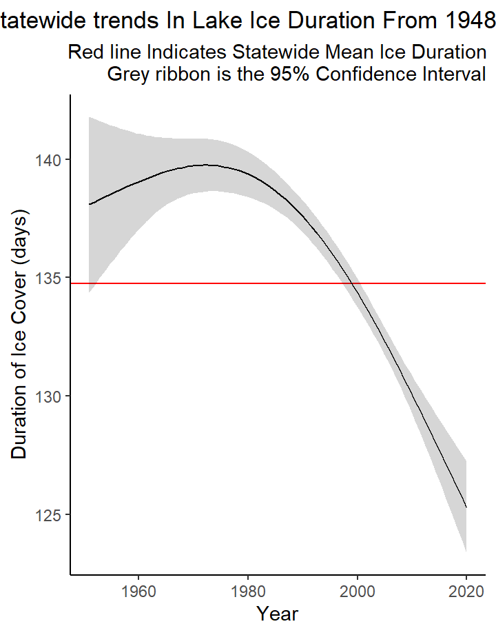

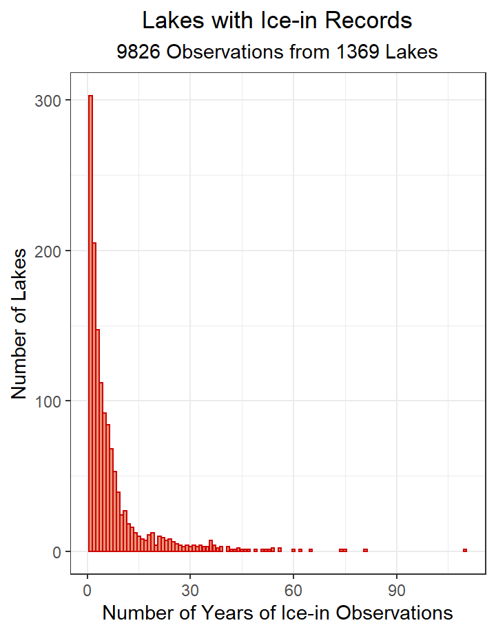

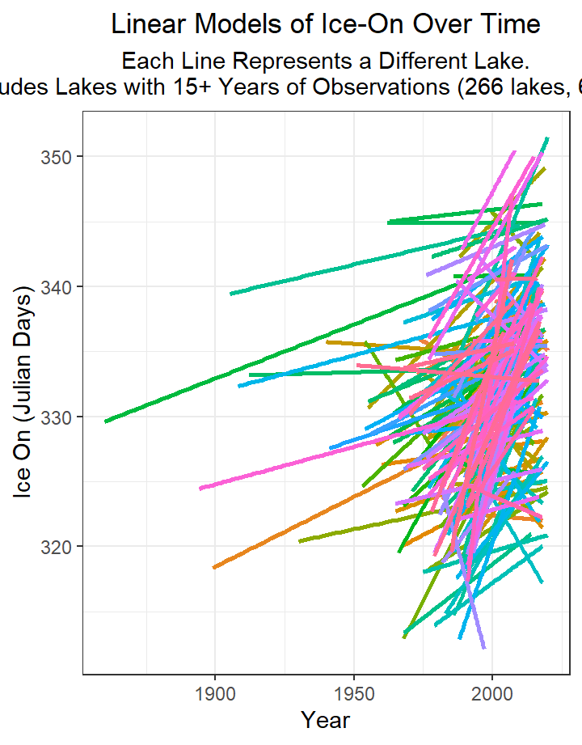

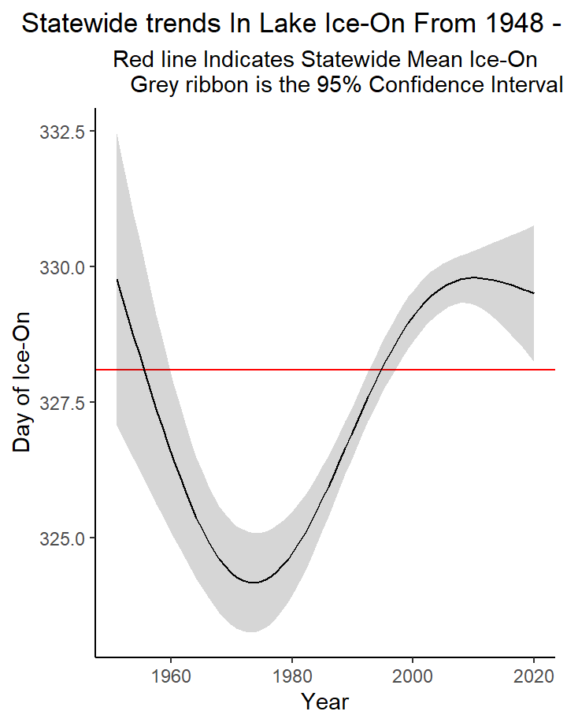

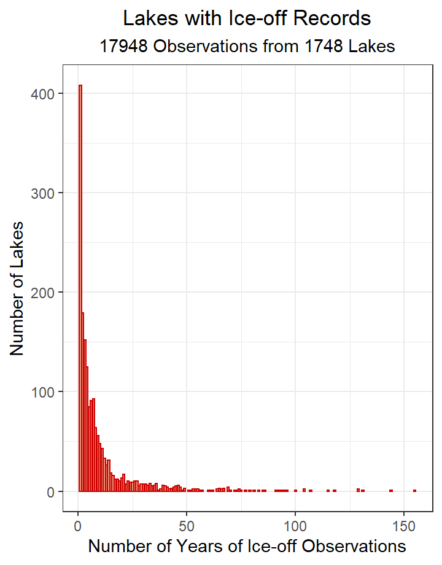

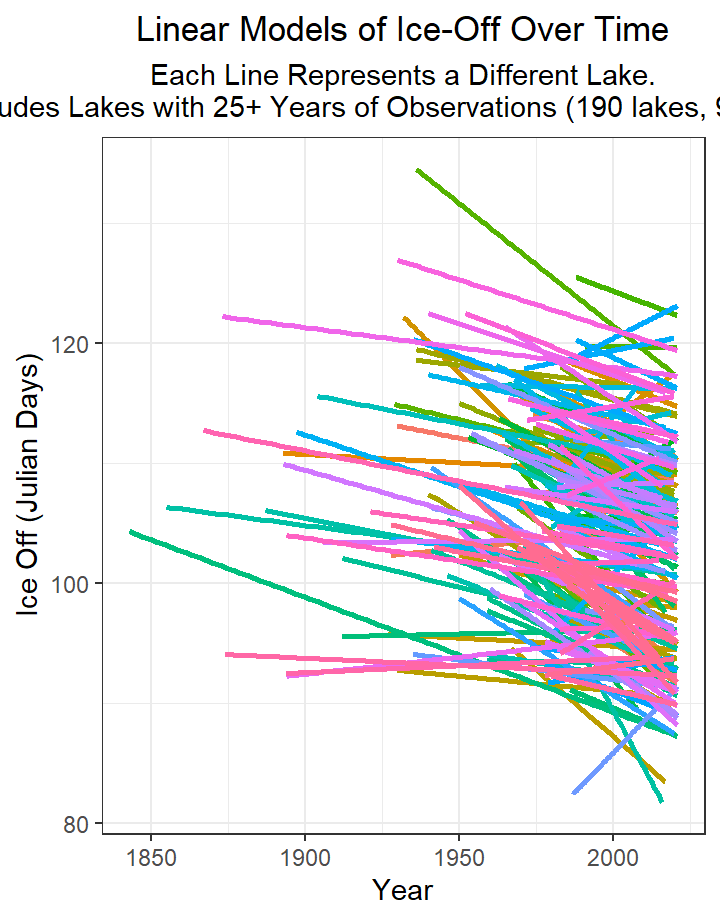

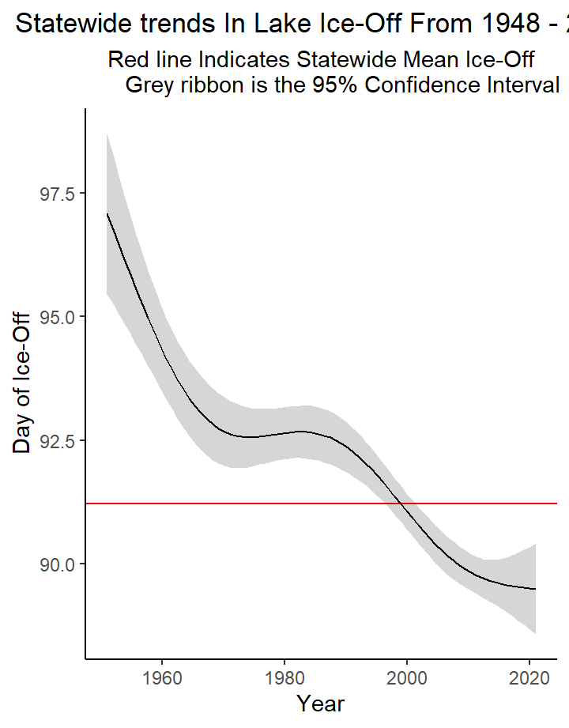

# Ice Duration

### **About Lake Ice Data**

The lake ice data you can find here is almost entirely collected by community scientists and submitted to the Minnesota DNR. The definition of when lake ice comes on or goes off varies from lake to lake. Some reporters consider lake ice to be off when the lake is 100% ice free, while others consider ice to be off when certain sections of the lake are navigable by boats. The important thing is that observers use consistent criteria when determining when lake ice goes on or comes off. Community scientist reporting lake ice data allows for observations on many more lakes then researchers would be able to record!

### **Ice Duration Histogram**

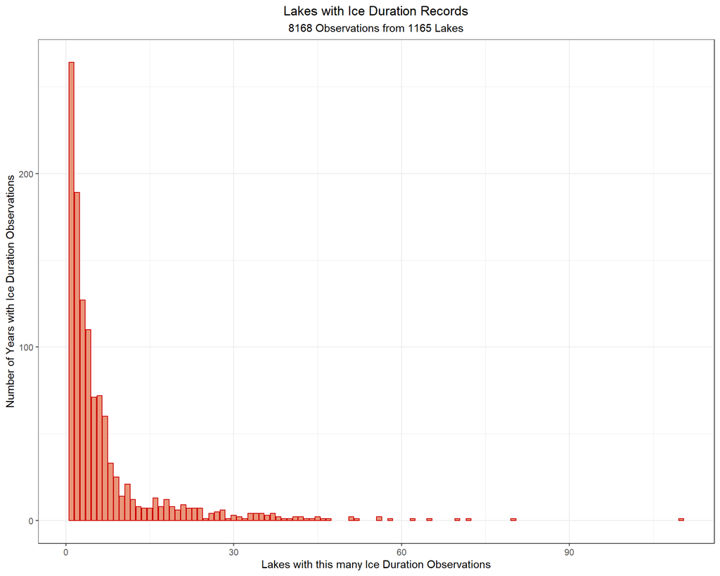

### **Spatial Scatterplot of Mean Ice Duration**

[interactive chart not shown]

### **Ice Data Submission**

Scroll around and checkout lakes you know! Don’t see your lake? Consider submitting ice data from your lake to the Minnesota DNR Climatology Office. All you need to do is post the Lake name, county and date on the [MN DNR Climatology Facebook Page](https://www.facebook.com/MinnesotaStateClimatologyOffice).

### **Trends of Ice Duration**

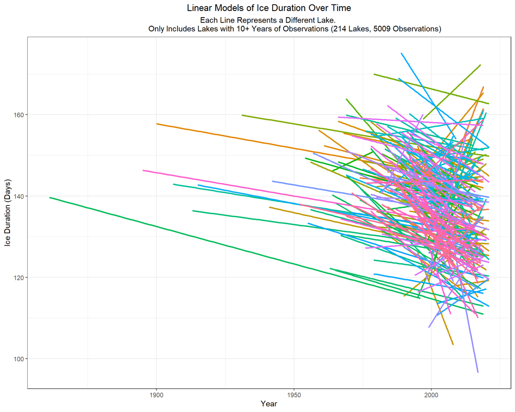

### **Trends of Ice Duration Comments**

This plot does a nice job of showing the lake to lake variability. There are lakes that have ice duration decreasing rapidly and lakes that have an increase in ice duration. Some lakes have long term data (150+ years) and some lake only have data from 2010-2020. One way to account for this messy data is to use non-linear mixed models. Non-linear because the decrease the change in ice duration likely isn’t the same in 1960 as it is in 2020. Mixed models simply mean we account for repeated measurements from the same lakes. The plot below indicates the statewide trend in ice duration. If you are interested in the gritty modeling details feel free to check out the “modeling” tab on the main page.

### **Modeled Trends in Minnesota Ice Duration**

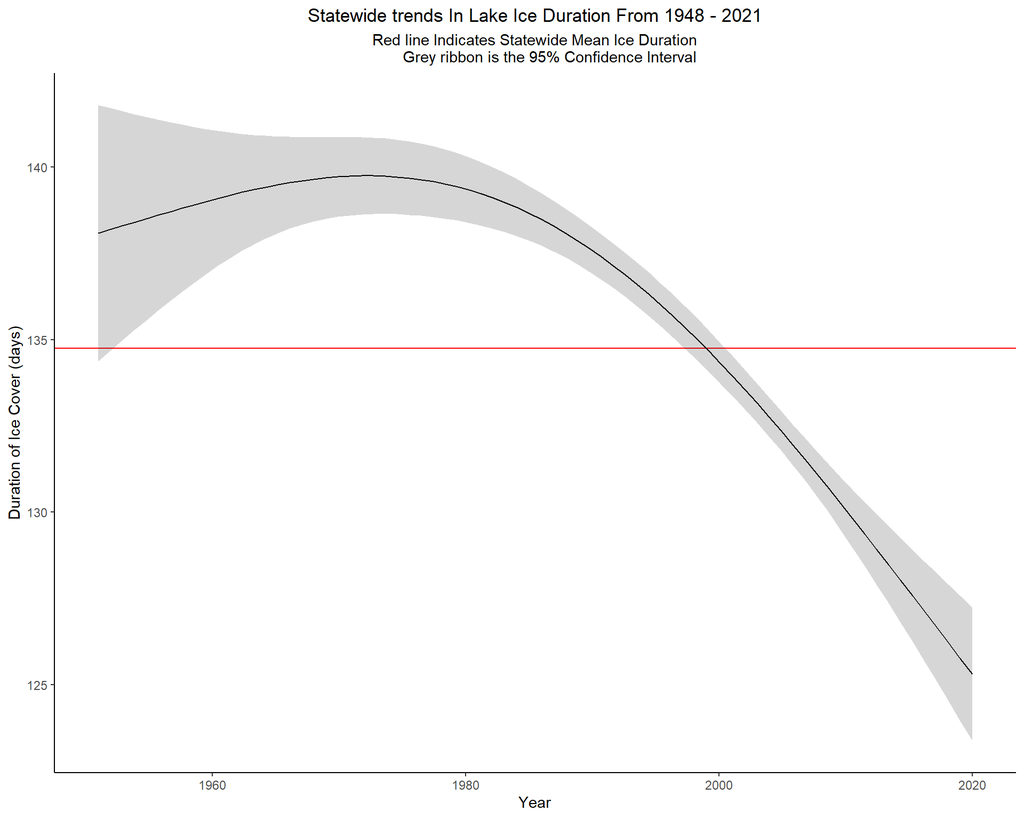

# Ice-On

### **Ice-On Data Histogram**

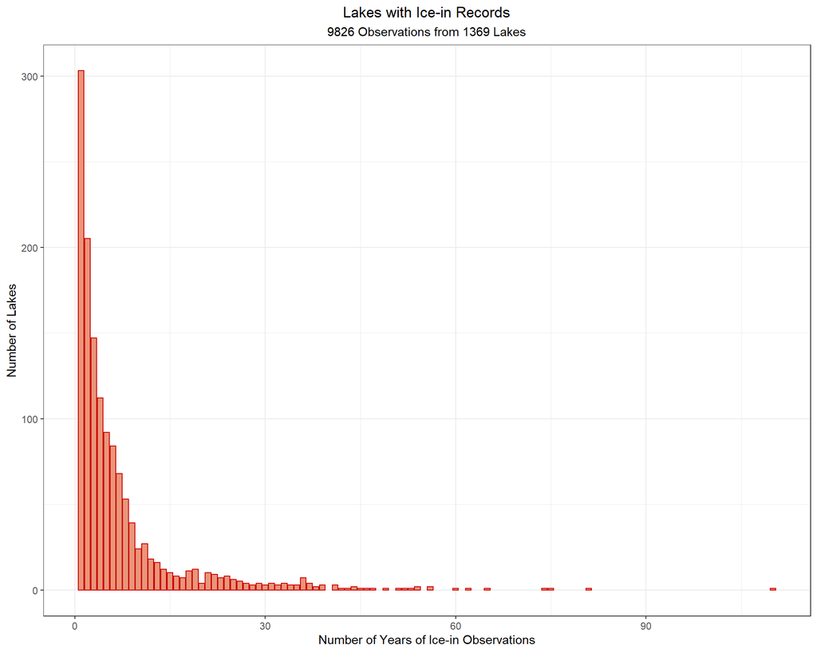

### **Spatial Scatterplot of Ice-On**

[interactive chart not shown]

### **Trends of Ice-On**

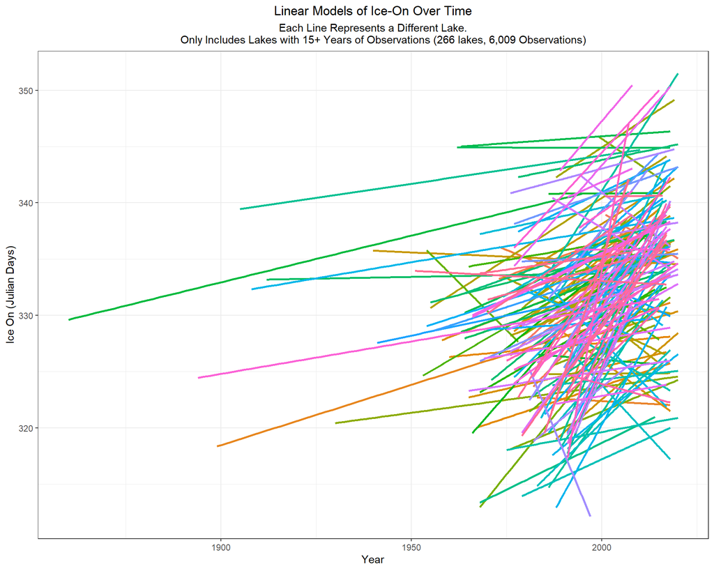

### **Trends of Ice-On Comments**

Once again this plot really illustrates the variability of lake ice. There is a whole lot going on near the start of the 21st century. What we would expect with climate change is that ice-on becomes later in the year (the line is increasing). It appears like many lakes have this trend but some lakes also seem to show lakes freezing earlier in the year. Below you can find what our models show (and once again the gritty details can be found on the “modeling” tab).

### **Modeled Trends in Minnesota Ice-On**

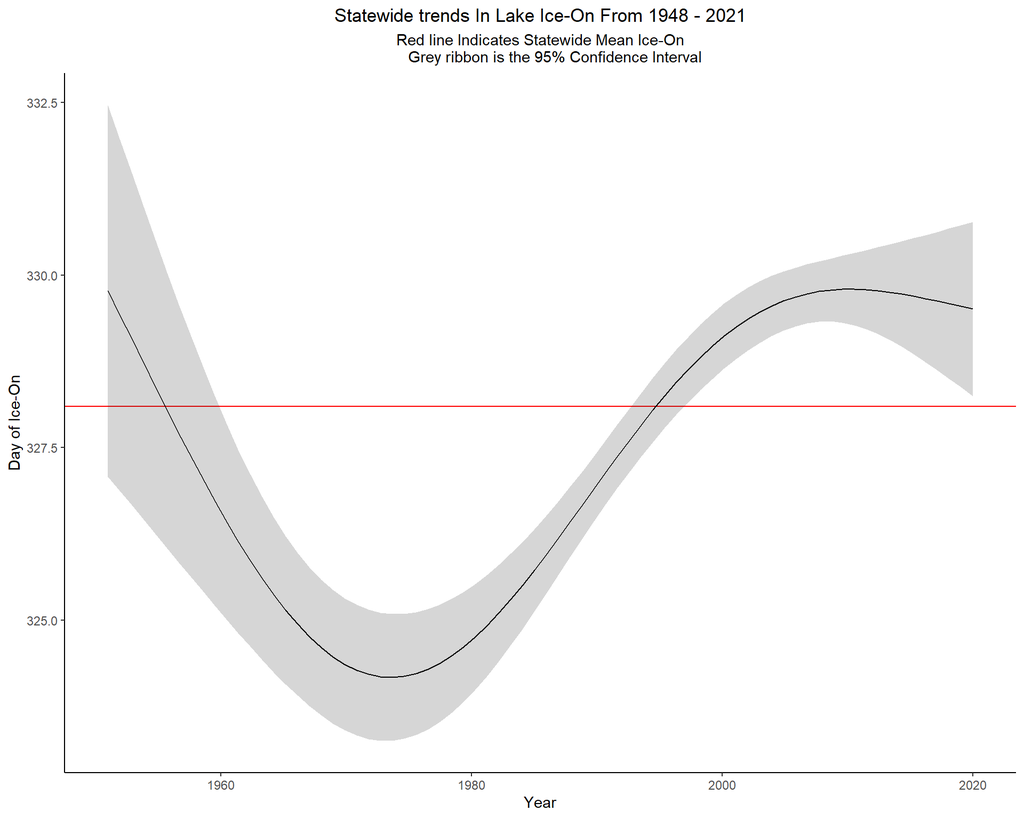

# Ice-Off

### **Ice-Off Histogram**

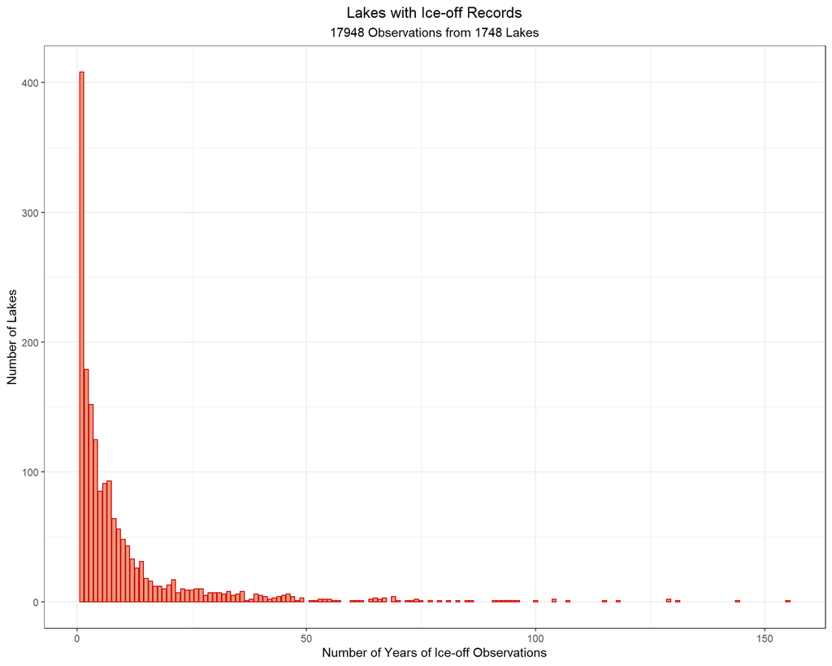

[interactive chart not shown]

### **Trends of Ice-Off**

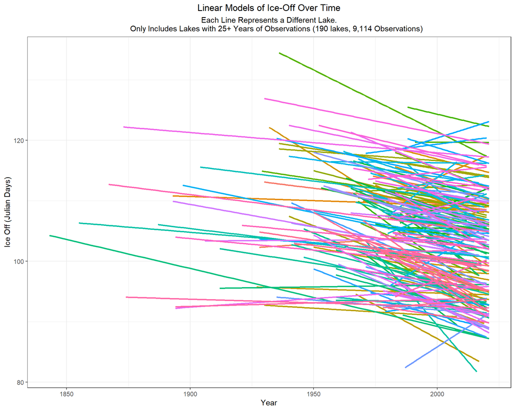

### **Modeled Trends in Minnesota Ice-Off**

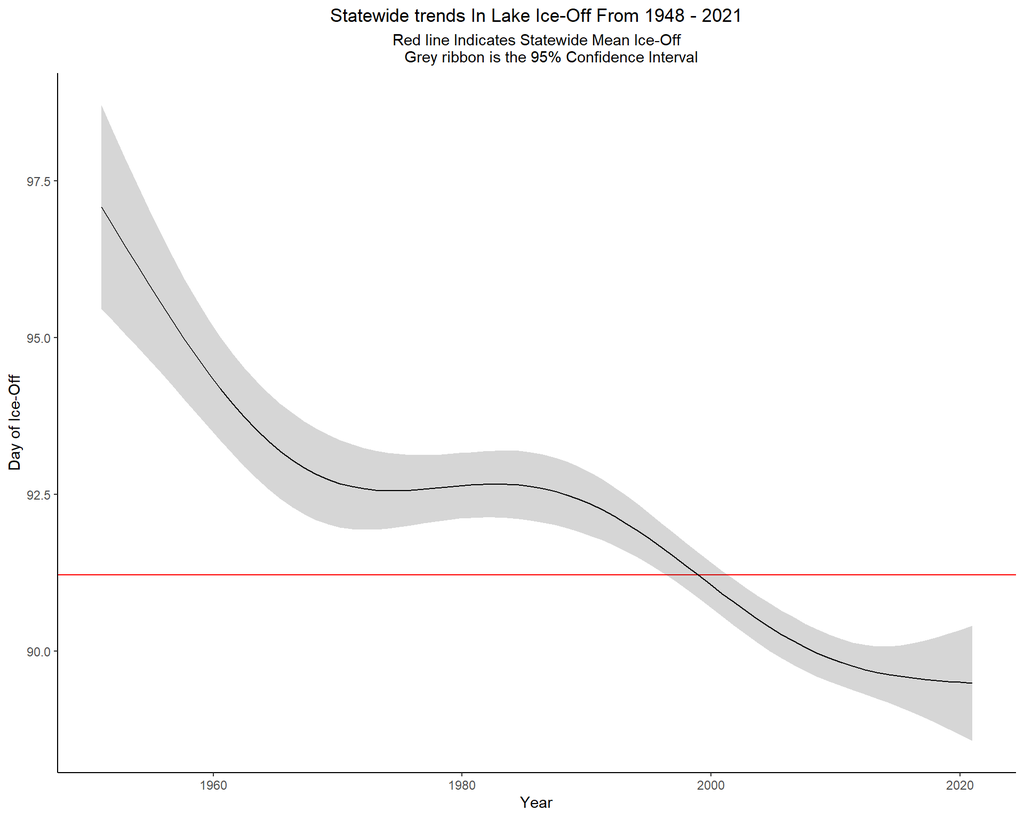